# P2

```python
import pandas, sqlite3, matplotlib.pyplot as plt, numpy as np
```

```python
### Problem 1

# Connect to the database and create a datafram from the query below.
# More infor on query below.

sqlite_file = 'lahman2014.sqlite'
conn = sqlite3.connect(sqlite_file)

query = """with pay as
           (select yearid, teamid, sum(salary) as total_payroll from salaries group by yearid, teamid),
           wr as
           (select yearid, teamid, franchid, w, g, (cast(w as real) / g) * 100 as win_rate from teams)
           select * from pay natural join wr;"""
res = pandas.read_sql(query, conn)
res
```

|  | yearid | teamid | total_payroll | franchid | w | g | win_rate |
| --- | --- | --- | --- | --- | --- | --- | --- |
| 0 | 1985 | ATL | 14807000.0 | ATL | 66 | 162 | 40.740741 |
| 1 | 1985 | BAL | 11560712.0 | BAL | 83 | 161 | 51.552795 |
| 2 | 1985 | BOS | 10897560.0 | BOS | 81 | 163 | 49.693252 |
| 3 | 1985 | CAL | 14427894.0 | ANA | 90 | 162 | 55.555556 |
| 4 | 1985 | CHA | 9846178.0 | CHW | 85 | 163 | 52.147239 |
| ... | ... | ... | ... | ... | ... | ... | ... |
| 853 | 2014 | SLN | 120693000.0 | STL | 90 | 162 | 55.555556 |
| 854 | 2014 | TBA | 72689100.0 | TBD | 77 | 162 | 47.530864 |
| 855 | 2014 | TEX | 112255059.0 | TEX | 67 | 162 | 41.358025 |
| 856 | 2014 | TOR | 109920100.0 | TOR | 83 | 162 | 51.234568 |
| 857 | 2014 | WAS | 131983680.0 | WSN | 96 | 162 | 59.259259 |

858 rows × 7 columns

I used the following query to get the total payroll for each team for each year:

```
select yearid, teamid, sum(salary) as total_payroll
from salaries
group by yearid, teamid;
```

I used this second query to get the winrate for each team for each year recorded in the Teams relation:

```
select yearid, teamid, franchid, w, g, (cast(w as real) / g) * 100 as win_rate
from teams;
```

Looking at the resulting number of rows from the two queries, it was apparent that the salaries relation was missing payroll data for some teams for some years. To deal with the missing data, I chose to use a natural join which would merge the data for team and year combination that existed in both tables.

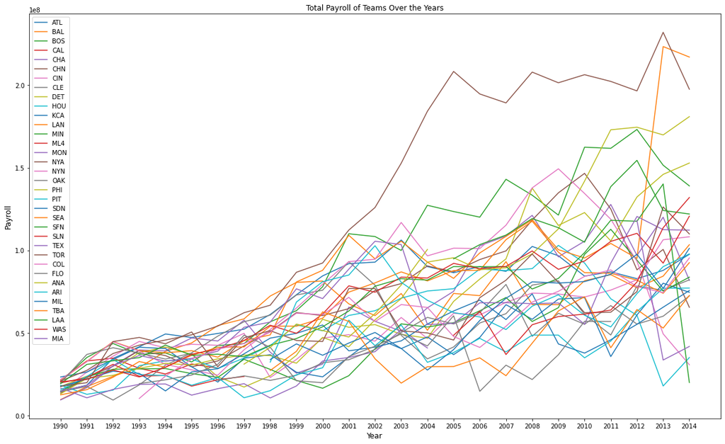

```python
### Problem 2

# Filtered for all data between [1990, 2014]
# For each team in the database, plotted their total spendings over the years in a line graph.
# Set the team names (TeamID) as the labels for the legend.

filtered = res.loc[res['yearid'] >= 1990]

plt.figure(figsize = (20, 12))
plt.title('Total Payroll of Teams Over the Years')
plt.xlabel('Year', size=12)
plt.ylabel('Payroll', size=12)
plt.xticks(np.arange(1990, 2015))

for teams in filtered['teamid'].unique():
  team_data = filtered.loc[filtered['teamid'] == teams]
  plt.plot(team_data['yearid'], team_data['total_payroll'], label = teams)

plt.legend()
plt.show()
```

### Question 1

From this line graph we can clearly see that there is an upward trend meaning that for the most part each team saw an increase in payroll over time. However, we can also see that some teams that saw an increase in payroll in earlier years are now seeing a decrease in payrolls in recent years. The spread of the payrolls between teams also saw an increase over the years. We see that in the beginning, at 1990, all teams had very similar total payrolls. By 2014, there is signficant difference between the teams with the highest and lowest payrolls. This graph can additionally be used analyze the average total payrolls for all teams over time.

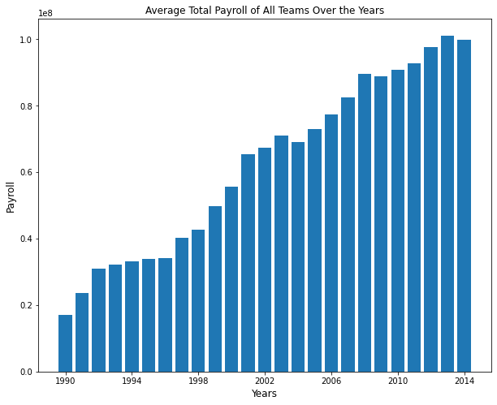

```python
### Problem 3

# Got the unique list of years in the database and found the average payroll for all teams for each year.
# Plotted the data to get a bar graph of average total payroll over the years.

trend_x = filtered['yearid'].unique()
trend_y = filtered.groupby(['yearid'])['total_payroll'].mean().values

plt.figure(figsize = (10, 8))
plt.title('Average Total Payroll of All Teams Over the Years')
plt.xlabel('Years', size=12)
plt.ylabel('Payroll', size=12)
plt.xticks(np.arange(1990, 2015, 4))

plt.bar(trend_x, trend_y)
plt.show()
```

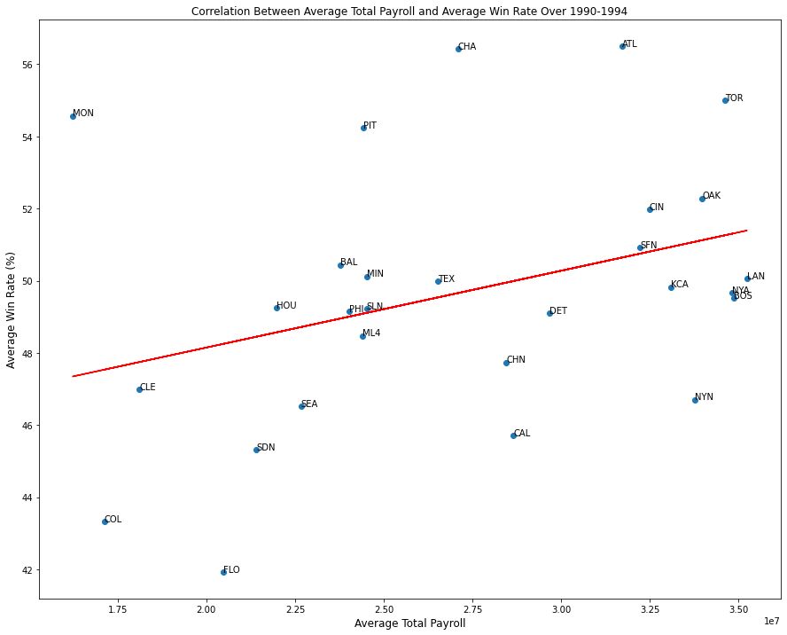

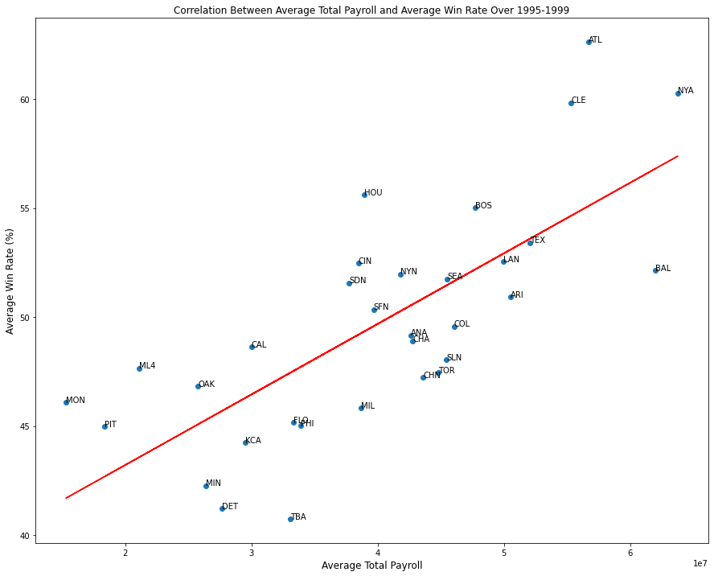

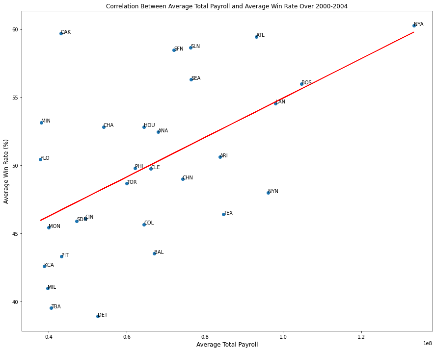

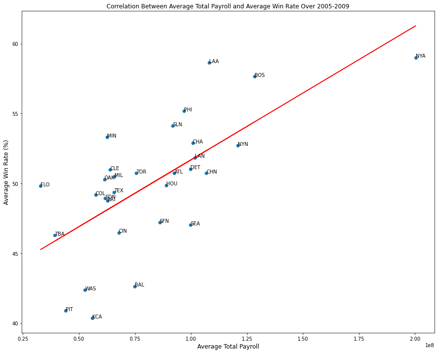

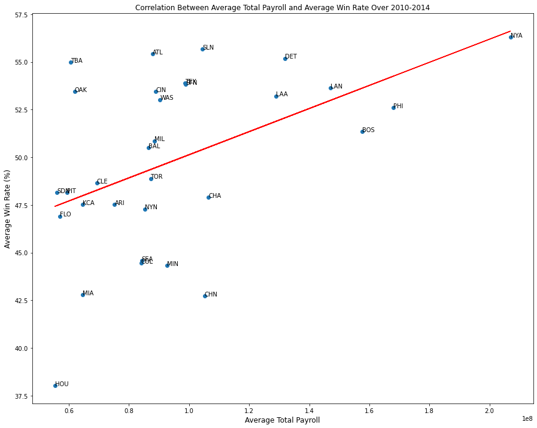

```python
### Problem 4

# Divided the years from 1990-2014 into 5 groups with each starting year as 1990, 1995, 2000, 2005, 2010
# Incremented by 5s to not double count the ending year for periods (ie, 1990-1994, 1994-1998)
# Separated the dataframe using pandas.cut() into 5 bins by their yearid and labeled rows in each bin by the starting year of their period
# For each period, found the average total payroll and win rate for each team during the period
# Plotted the data using a scatterplot and included a regression line found using numpy.ployfit()
# For each scatterplot, iterated through each point and annotated the team name

ptable = filtered.copy()
periods = np.arange(1990, 2014, 5)
ptable['period'] = pandas.cut(x=ptable['yearid'], bins=5, labels=periods)

for period in periods:
  temp = ptable.loc[ptable['period'] == period]
  avg_pay = temp.groupby(['teamid'])['total_payroll'].mean().to_frame()
  avg_wr = temp.groupby(['teamid'])['win_rate'].mean().to_frame()

  avg = avg_pay.merge(avg_wr, how='inner', on='teamid')
  avg['team'] = avg.index

  plt.figure(figsize=(15,12))
  title = "Correlation Between Average Total Payroll and Average Win Rate Over {}-{}".format(period, period + 4)
  plt.title(title)
  plt.xlabel('Average Total Payroll', size=12)
  plt.ylabel('Average Win Rate (%)', size=12)
  plt.scatter(avg['total_payroll'], avg['win_rate'])

  x = avg['total_payroll'].values
  y = avg['win_rate'].values
  a, b = np.polyfit(x, y, 1)
  plt.plot(x, a * x + b, "r-")

  for k, v in enumerate(avg['team']):
    plt.annotate(v, (avg['total_payroll'][k], avg['win_rate'][k]), size = 10)

  plt.show()
```

### Question 2

Refering to the graphs generated for each period, it is apparent by looking at the regression line that there is a positive correlation between the average total payroll and the average win rate. In other words, generally, the more money a team spends, the higher their win rate. Two teams that really stood out in these graphs were NYA and ATL. Throughout the periods, it is apparent that NYA has consistently spent the most out of any other team and as a result they maintained one of the highest win rates through the years (excluding 1990-1994). ATL on the other hand was a team that initially had high spendings like NYA but over the years has successfully managed to maintain a high win rate while cutting back on their spendings. Taking a look at OAK, it appears that they took a similar approach to ATL. In the 1990-1994 period, OAK spent as much as some of the highest spending teams and saw a relatively high win rate. But over the years, they would cut back on their spendings while maintaining win rates higher than the average win rate at their spending range (indicated by the regression line). While their win rates fluctuated throughout the years dropping significantly during the 1995-1999 and 2005-2009 periods, they generally had a relatively high spending efficiency. The team's spending to win rate ratio peaked in the 2000-2004 period when it achieved one of the highest win rates out of all teams while spending than most other teams.

```python
### Problem 5

# Found the mean and standard deviation for all teams' payroll by each year
# Applied the given formula to add the standardized payroll column

standardized = filtered.copy()
standardized['avg_pay'] = standardized['total_payroll'].groupby(standardized['yearid']).transform('mean')
standardized['std'] = standardized['total_payroll'].groupby(standardized['yearid']).transform('std')

def get_stdpay(pay, meanpay, std):
  return (pay - meanpay) / std

standardized['stdpay'] = standardized.apply(lambda x : get_stdpay(x['total_payroll'], x['avg_pay'], x['std']), axis=1)

standardized
```

|  | yearid | teamid | total_payroll | franchid | w | g | win_rate | avg_pay | std | stdpay |
| --- | --- | --- | --- | --- | --- | --- | --- | --- | --- | --- |
| 130 | 1990 | ATL | 14555501.0 | ATL | 65 | 162 | 40.123457 | 1.707235e+07 | 3.771834e+06 | -0.667275 |
| 131 | 1990 | BAL | 9680084.0 | BAL | 76 | 161 | 47.204969 | 1.707235e+07 | 3.771834e+06 | -1.959861 |
| 132 | 1990 | BOS | 20558333.0 | BOS | 88 | 162 | 54.320988 | 1.707235e+07 | 3.771834e+06 | 0.924213 |
| 133 | 1990 | CAL | 21720000.0 | ANA | 80 | 162 | 49.382716 | 1.707235e+07 | 3.771834e+06 | 1.232198 |
| 134 | 1990 | CHA | 9491500.0 | CHW | 94 | 162 | 58.024691 | 1.707235e+07 | 3.771834e+06 | -2.009859 |
| ... | ... | ... | ... | ... | ... | ... | ... | ... | ... | ... |
| 853 | 2014 | SLN | 120693000.0 | STL | 90 | 162 | 55.555556 | 9.980002e+07 | 4.570505e+07 | 0.457126 |
| 854 | 2014 | TBA | 72689100.0 | TBD | 77 | 162 | 47.530864 | 9.980002e+07 | 4.570505e+07 | -0.593171 |
| 855 | 2014 | TEX | 112255059.0 | TEX | 67 | 162 | 41.358025 | 9.980002e+07 | 4.570505e+07 | 0.272509 |
| 856 | 2014 | TOR | 109920100.0 | TOR | 83 | 162 | 51.234568 | 9.980002e+07 | 4.570505e+07 | 0.221422 |
| 857 | 2014 | WAS | 131983680.0 | WSN | 96 | 162 | 59.259259 | 9.980002e+07 | 4.570505e+07 | 0.704160 |

728 rows × 10 columns

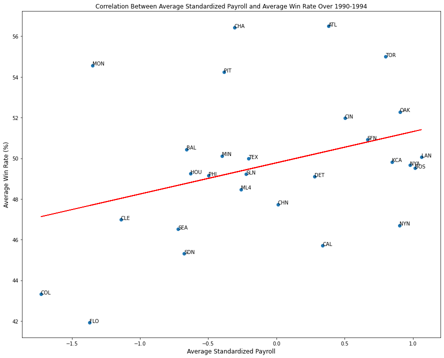

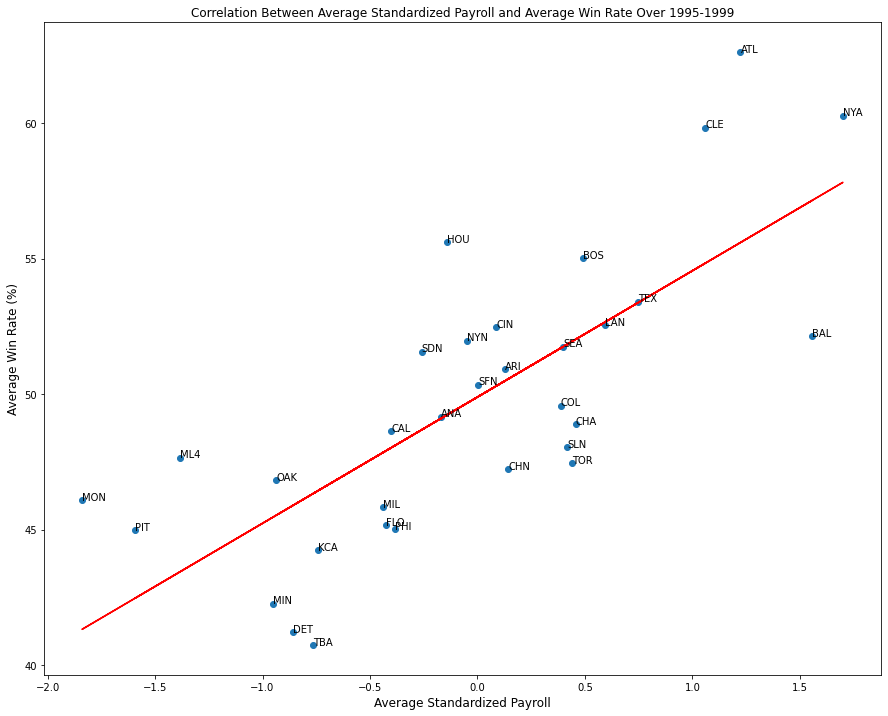

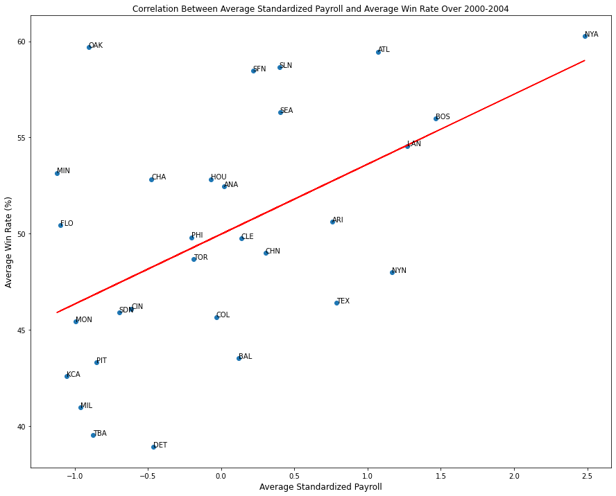

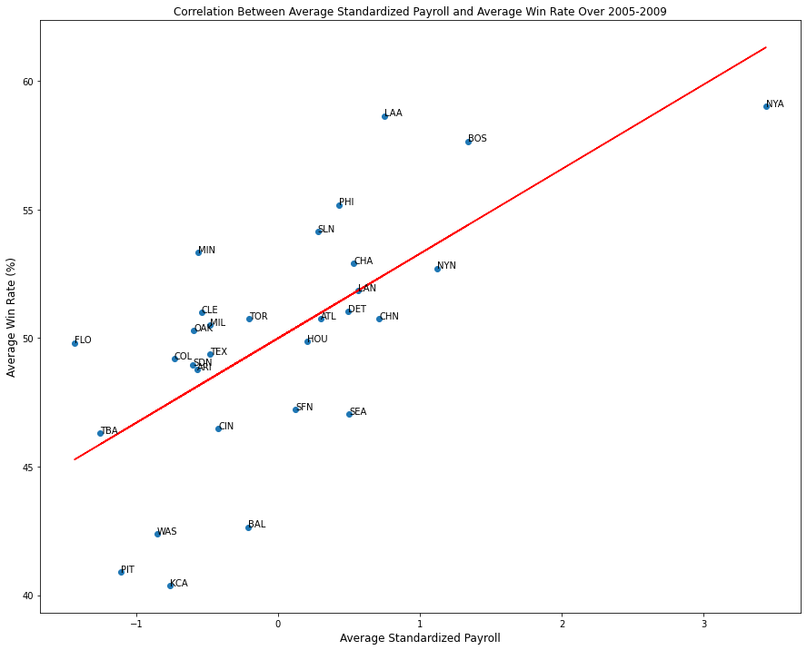

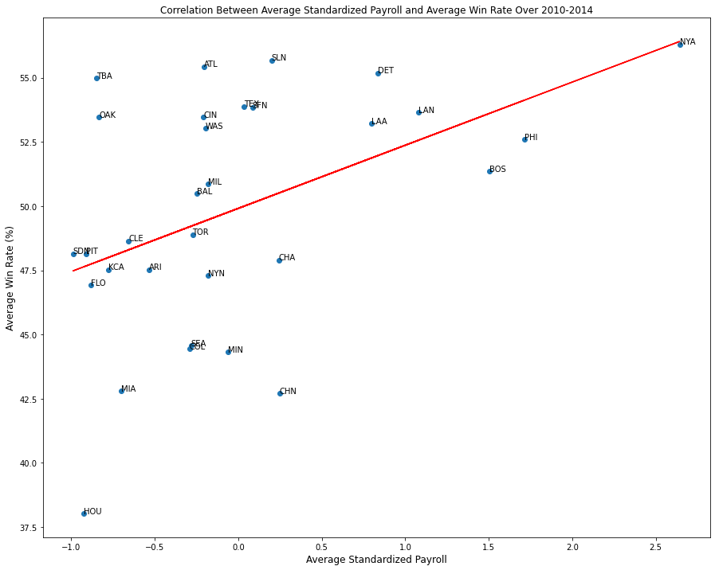

```python
### Problem 6

# Essentially did the thing mentioned in Problem 4's comments except this time found the average standardized payroll for each team
# and used that data instead of average total payroll.

ptable2 = standardized.drop(['avg_pay', 'std'], axis=1).copy()
ptable2['period'] = pandas.cut(x=ptable['yearid'], bins=5, labels=periods)

for period in periods:
  temp = ptable2.loc[ptable2['period'] == period]
  stdpay = temp.groupby(['teamid'])['stdpay'].mean().to_frame()
  avg_wr = temp.groupby(['teamid'])['win_rate'].mean().to_frame()

  avg = avg_wr.merge(stdpay, how='inner', on='teamid')
  avg['team'] = avg.index

  plt.figure(figsize=(15,12))
  title = "Correlation Between Average Standardized Payroll and Average Win Rate Over {}-{}".format(period, period + 4)
  plt.title(title)
  plt.xlabel('Average Standardized Payroll', size=12)
  plt.ylabel('Average Win Rate (%)', size=12)
  plt.scatter(avg['stdpay'], avg['win_rate'])

  x = avg['stdpay'].values
  y = avg['win_rate'].values
  a, b = np.polyfit(x, y, 1)
  plt.plot(x, a * x + b, "r-")

  for k, v in enumerate(avg['team']):
    plt.annotate(v, (avg['stdpay'][k], avg['win_rate'][k]), size = 10)

  plt.show()
```

### Question 3

The scatter points and lines of best fit from Problem 4 are almost identical to the ones generated by problem 6. The main difference of the plots generated by the two problems is the representation on the x-axis. In Problem 4, the x-axis for each plot only represented the average total payroll of each team for each time period, but the payroll amount does not tell us much about the data. In Problem 6, the x-axis is the average standardized payroll which can be used to analyze for each team's average payroll during that period, how many standard deviations away is it from the average payroll of all teams in that period. We can see that the scale of the x-axes for the plots in Problem 6 include negatives and positives indicating whether a team's spendings is below or above the average payroll of all teams, respectively.

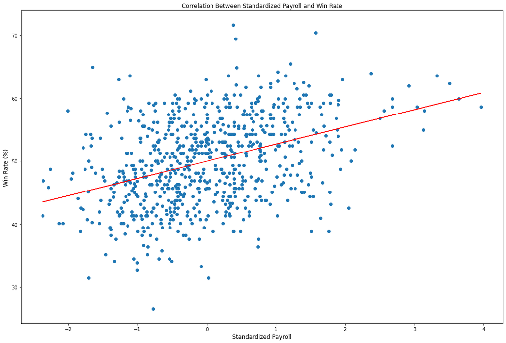

```python
### Problem 7

# Did the same thing as Problem 6 instead this time, removed the periods part
# Didn't use the average standardized payroll and win rate for each period
# Plotted standardized payroll and win rate for all years and all teams
# Found regression line using numpy.polyfit()

ptable3 = standardized.drop(['avg_pay', 'std'], axis=1).copy()

plt.figure(figsize=(18,12))
title = "Correlation Between Standardized Payroll and Win Rate"
plt.title(title)
plt.xlabel('Standardized Payroll', size=12)
plt.ylabel('Win Rate (%)', size=12)
plt.scatter(ptable3['stdpay'], ptable3['win_rate'])

x = ptable3['stdpay'].values
y = ptable3['win_rate'].values
a, b = np.polyfit(x, y, 1)
plt.plot(x, a * x + b, "r-")

plt.show()
```

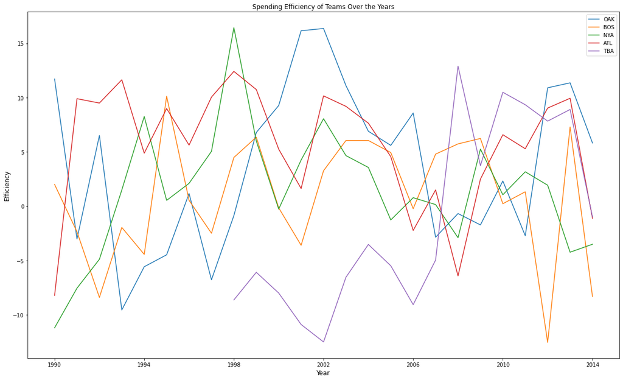

```python
### Problem 8

# Added the spending efficiency column using the formula provided
# Filtered the dataframe for the teams provided per instruction
# For each team, plotted spending efficiency over the years and labeled each team in legend

eff = standardized.drop(['avg_pay', 'std'], axis=1).copy()

def get_efficiency(wr, ew):
  return wr - ew

eff['exp_win'] = eff['stdpay'].apply(lambda x : 50 + (2.5 * x))
eff['efficiency'] = eff.apply(lambda x : get_efficiency(x['win_rate'], x['exp_win']), axis=1)
selected_teams = ['OAK', 'BOS', 'NYA', 'ATL', 'TBA']

plt.figure(figsize = (20, 12))
plt.title('Spending Efficiency of Teams Over the Years')
plt.xlabel('Year', size=12)
plt.ylabel('Efficiency', size=12)
plt.xticks(np.arange(1990, 2015, 4))

for team in selected_teams:
  team_data = eff.loc[eff['teamid'] == team]
  plt.plot(team_data['yearid'], team_data['efficiency'], label = team)

plt.legend()
plt.show()
```

### Question 4

From this plot we can see that Oakland A's spending efficiency fluctuated a lot over the years. Oakland A's spending efficiency during the Moneyball period was significantly higher than any other team during that period and maintains as one of the highest spending efficiency of all teams during the entire 1990-2014 period that was studied. They started off with a high spending efficiency in their first year, but they struggled around 1993-1997 before going back up. They saw some struggle again around 2007-2011, but the spending efficiency was nowhere as bad as 1993-1997. For the last remaining years, they seem to have a relatively high spending efficiency. This plots reflects with what I had concluded from looking at the plots in Question 2 and 3, but offers more insight on the magnitude of their success and failures over the years represented using the numerical spending efficiency value. From the previous plots, I was able to notice that during the 1993-1997 and 2007-2011 periods they had lower win rates compared to other years, but I was not able to conclude how much worse they were performing during 1993-1997 compared to 2007-2011 as shown in this plot here.